# HT3

Stefan Quintana, Sofía Escobar, Wilfredo Gallegos

3/7/2023

```
## 'data.frame':    1460 obs. of  81 variables:
##  $ Id           : int  1 2 3 4 5 6 7 8 9 10 ...
##  $ MSSubClass   : int  60 20 60 70 60 50 20 60 50 190 ...
##  $ MSZoning     : chr  "RL" "RL" "RL" "RL" ...
##  $ LotFrontage  : int  65 80 68 60 84 85 75 NA 51 50 ...
##  $ LotArea      : int  8450 9600 11250 9550 14260 14115 10084 10382 6120 7420 ...
##  $ Street       : chr  "Pave" "Pave" "Pave" "Pave" ...
##  $ Alley        : chr  NA NA NA NA ...
##  $ LotShape     : chr  "Reg" "Reg" "IR1" "IR1" ...
##  $ LandContour  : chr  "Lvl" "Lvl" "Lvl" "Lvl" ...
##  $ Utilities    : chr  "AllPub" "AllPub" "AllPub" "AllPub" ...
##  $ LotConfig    : chr  "Inside" "FR2" "Inside" "Corner" ...
##  $ LandSlope    : chr  "Gtl" "Gtl" "Gtl" "Gtl" ...
##  $ Neighborhood : chr  "CollgCr" "Veenker" "CollgCr" "Crawfor" ...
##  $ Condition1   : chr  "Norm" "Feedr" "Norm" "Norm" ...
```

[output cut: 67 more lines]

```
##        Id           MSSubClass      MSZoning          LotFrontage
##  Min.   :   1.0   Min.   : 20.0   Length:1460        Min.   : 21.00
##  1st Qu.: 365.8   1st Qu.: 20.0   Class :character   1st Qu.: 59.00
##  Median : 730.5   Median : 50.0   Mode  :character   Median : 69.00
##  Mean   : 730.5   Mean   : 56.9                      Mean   : 70.05
##  3rd Qu.:1095.2   3rd Qu.: 70.0                      3rd Qu.: 80.00
##  Max.   :1460.0   Max.   :190.0                      Max.   :313.00
##                                                      NA's   :259
##     LotArea          Street             Alley             LotShape
##  Min.   :  1300   Length:1460        Length:1460        Length:1460
##  1st Qu.:  7554   Class :character   Class :character   Class :character
##  Median :  9478   Mode  :character   Mode  :character   Mode  :character
##  Mean   : 10517
##  3rd Qu.: 11602
##  Max.   :215245
##
##  LandContour         Utilities          LotConfig          LandSlope
##  Length:1460        Length:1460        Length:1460        Length:1460
##  Class :character   Class :character   Class :character   Class :character
##  Mode  :character   Mode  :character   Mode  :character   Mode  :character
##
##
##
##
##  Neighborhood        Condition1         Condition2          BldgType
##  Length:1460        Length:1460        Length:1460        Length:1460
##  Class :character   Class :character   Class :character   Class :character
##  Mode  :character   Mode  :character   Mode  :character   Mode  :character
##
##
##
##
##   HouseStyle         OverallQual      OverallCond      YearBuilt
##  Length:1460        Min.   : 1.000   Min.   :1.000   Min.   :1872
##  Class :character   1st Qu.: 5.000   1st Qu.:5.000   1st Qu.:1954
##  Mode  :character   Median : 6.000   Median :5.000   Median :1973
##                     Mean   : 6.099   Mean   :5.575   Mean   :1971
##                     3rd Qu.: 7.000   3rd Qu.:6.000   3rd Qu.:2000
##                     Max.   :10.000   Max.   :9.000   Max.   :2010
##
```

[output cut: 113 more lines]

```
##  Min.   : 1.000   Min.   :2006   Length:1460        Length:1460
##  1st Qu.: 5.000   1st Qu.:2007   Class :character   Class :character
##  Median : 6.000   Median :2008   Mode  :character   Mode  :character
##  Mean   : 6.322   Mean   :2008
##  3rd Qu.: 8.000   3rd Qu.:2009
##  Max.   :12.000   Max.   :2010
##
##    SalePrice
##  Min.   : 34900
##  1st Qu.:129975
##  Median :163000
##  Mean   :180921
##  3rd Qu.:214000
##  Max.   :755000
##
```

##P2 y P3. Analisis Exploratorio

No existen variables cuantitativas continuas.

En cuánto al análsis se puede notar en el archivo adjunto con los histogramas de las variables que ninguna variable parece respetar una distribución normal.

Para confirmar lo visto por los histogramas se le hará una prueba de normalidad a cada variable, si cada una presenta un valor-p menor a 0.05 se confirma la conclusión.

###MSSubClass

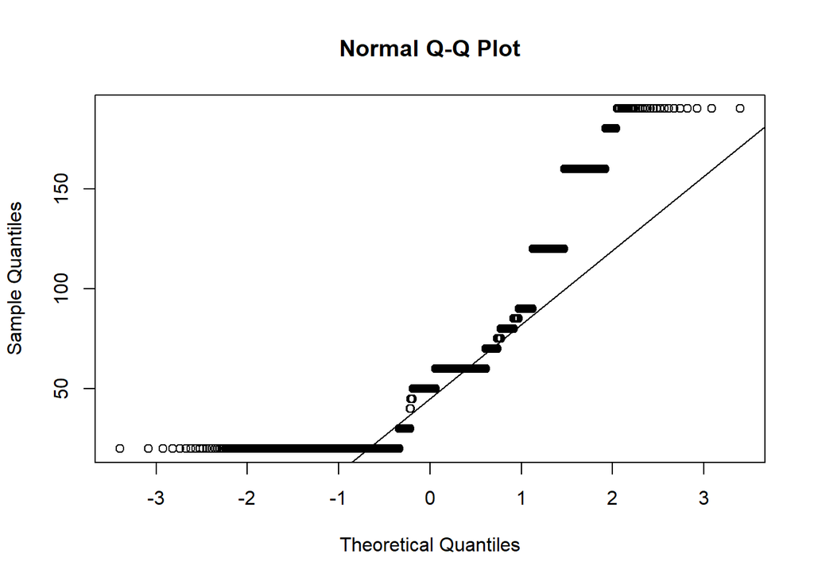

```
##
##  Lilliefors (Kolmogorov-Smirnov) normality test
##
## data:  datos$MSSubClass
## D = 0.19953, p-value < 2.2e-16
```

###LotFrontage

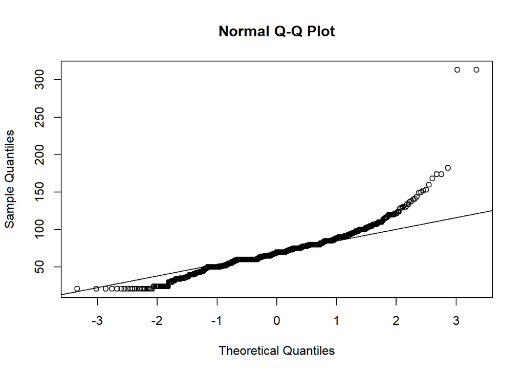

```
##
##  Lilliefors (Kolmogorov-Smirnov) normality test
##
## data:  datos$LotFrontage
## D = 0.10453, p-value < 2.2e-16
```

###LotArea

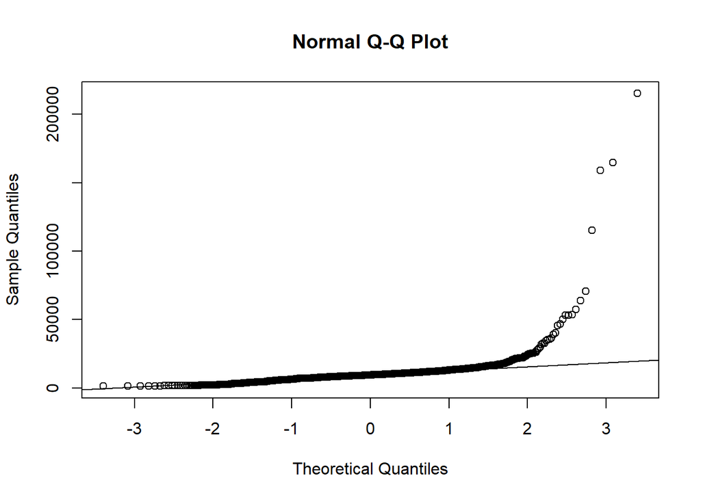

```
##
##  Lilliefors (Kolmogorov-Smirnov) normality test
##
## data:  datos$LotArea
## D = 0.25152, p-value < 2.2e-16
```

###OverallQual

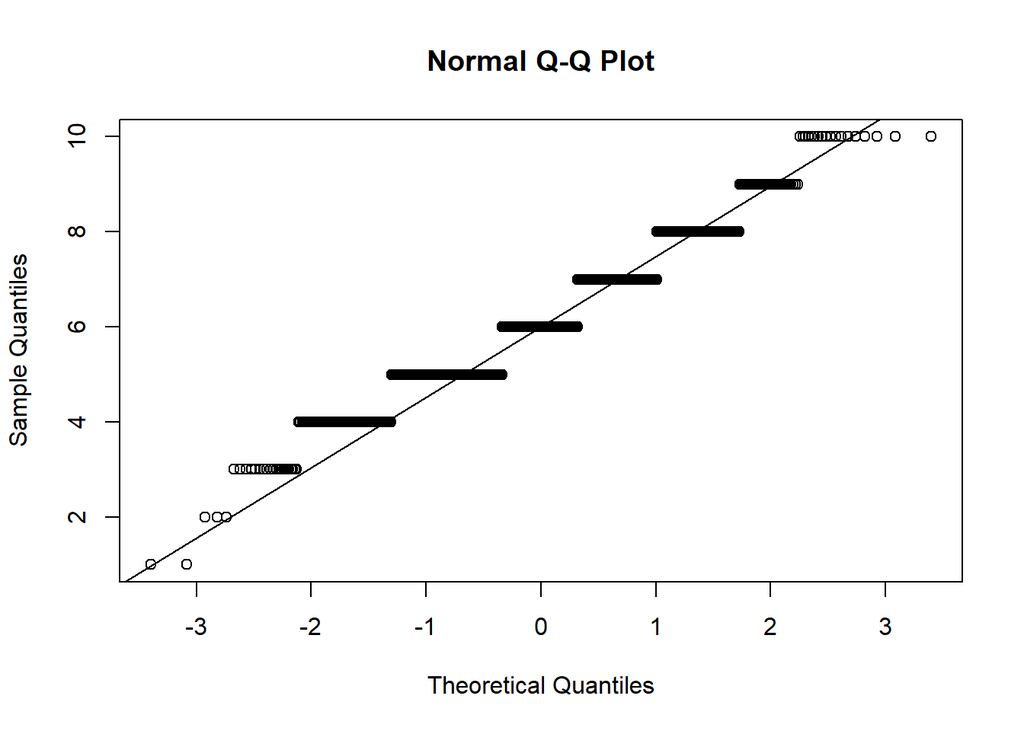

```
##
##  Lilliefors (Kolmogorov-Smirnov) normality test
##
## data:  datos$OverallQual
## D = 0.15515, p-value < 2.2e-16
```

###OverallCond

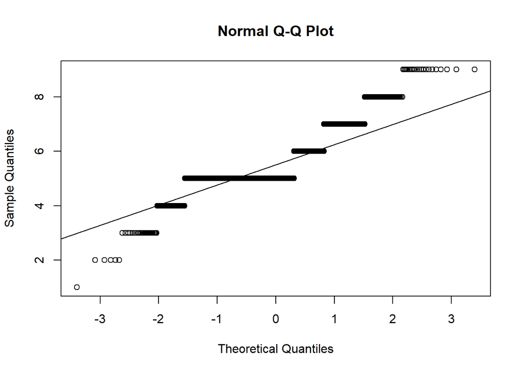

```
##
##  Lilliefors (Kolmogorov-Smirnov) normality test
##
## data:  datos$OverallCond
## D = 0.32003, p-value < 2.2e-16
```

###YearBuilt

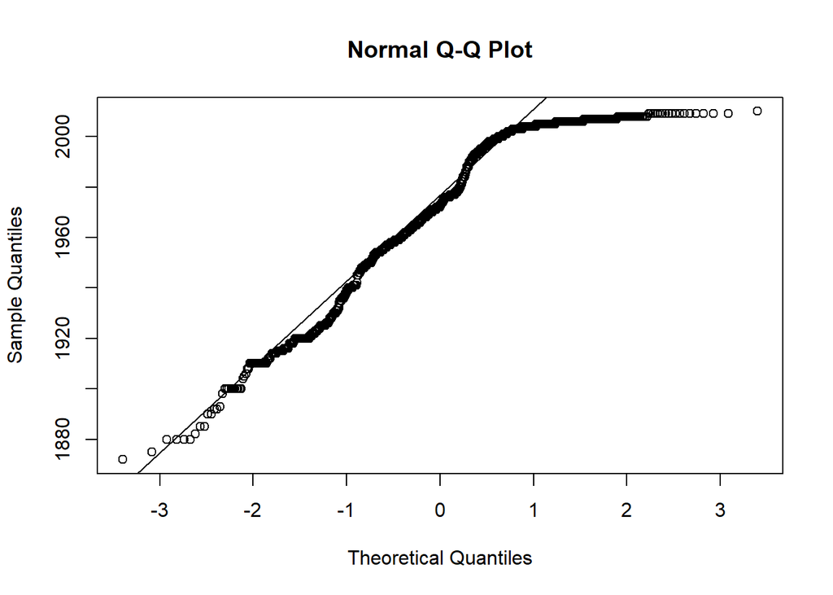

```
##
##  Lilliefors (Kolmogorov-Smirnov) normality test
##
## data:  datos$YearBuilt
## D = 0.12095, p-value < 2.2e-16
```

###YearRemodAdd

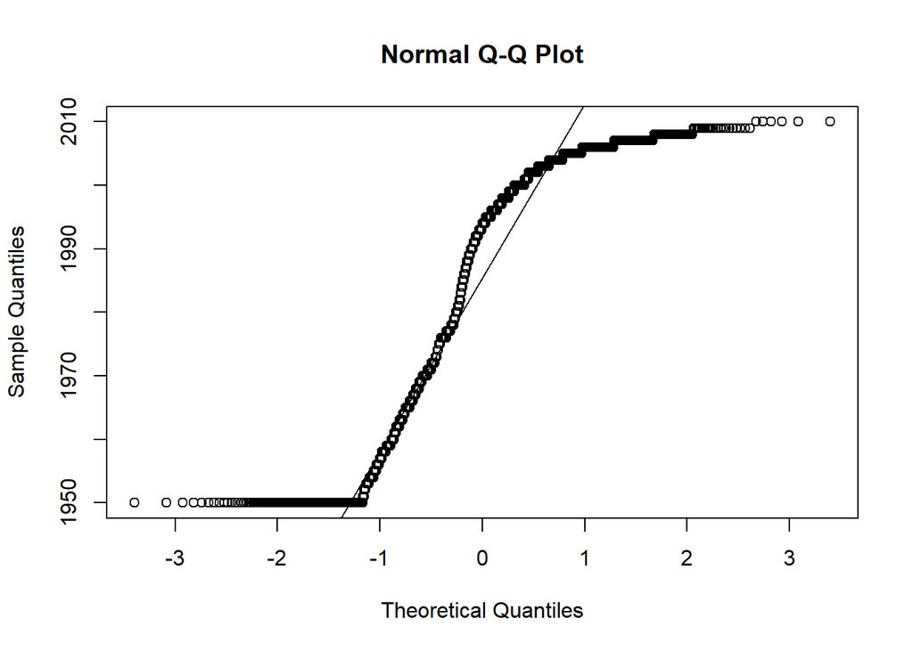

```
##
##  Lilliefors (Kolmogorov-Smirnov) normality test
##
## data:  datos$YearRemodAdd
## D = 0.17454, p-value < 2.2e-16
```

###MasVnrArea

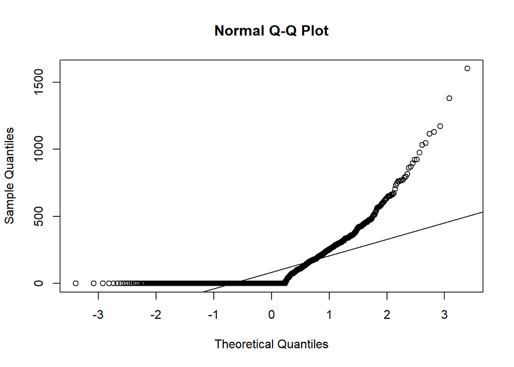

```
##
##  Lilliefors (Kolmogorov-Smirnov) normality test
##
## data:  datos$MasVnrArea
## D = 0.30953, p-value < 2.2e-16
```

###BsmtFinSF1

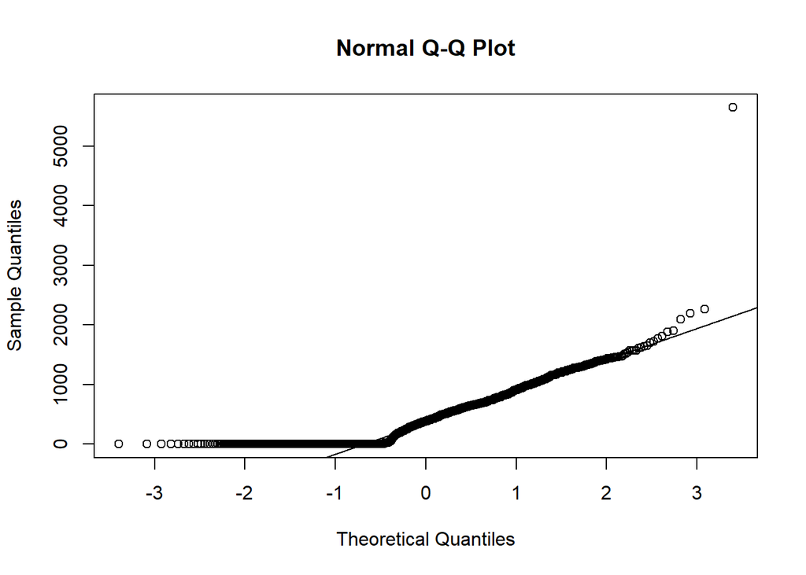

```
##
##  Lilliefors (Kolmogorov-Smirnov) normality test
##
## data:  datos$BsmtFinSF1
## D = 0.16535, p-value < 2.2e-16
```

###BsmtFinSF2

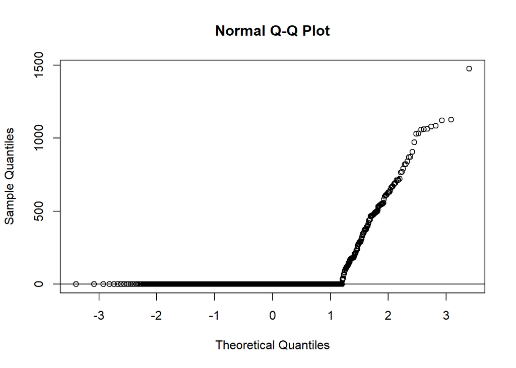

```
##
##  Lilliefors (Kolmogorov-Smirnov) normality test
##
## data:  datos$BsmtFinSF2
## D = 0.49916, p-value < 2.2e-16
```

###BsmtUnfSF

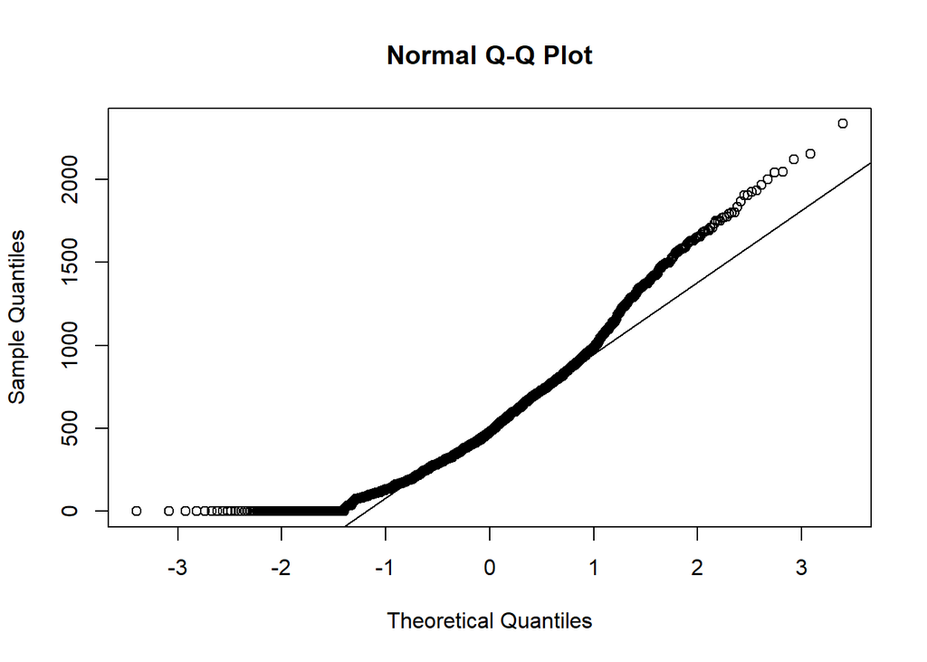

```
##
##  Lilliefors (Kolmogorov-Smirnov) normality test
##
## data:  datos$BsmtUnfSF
## D = 0.099617, p-value < 2.2e-16
```

###TotalBsmtSF

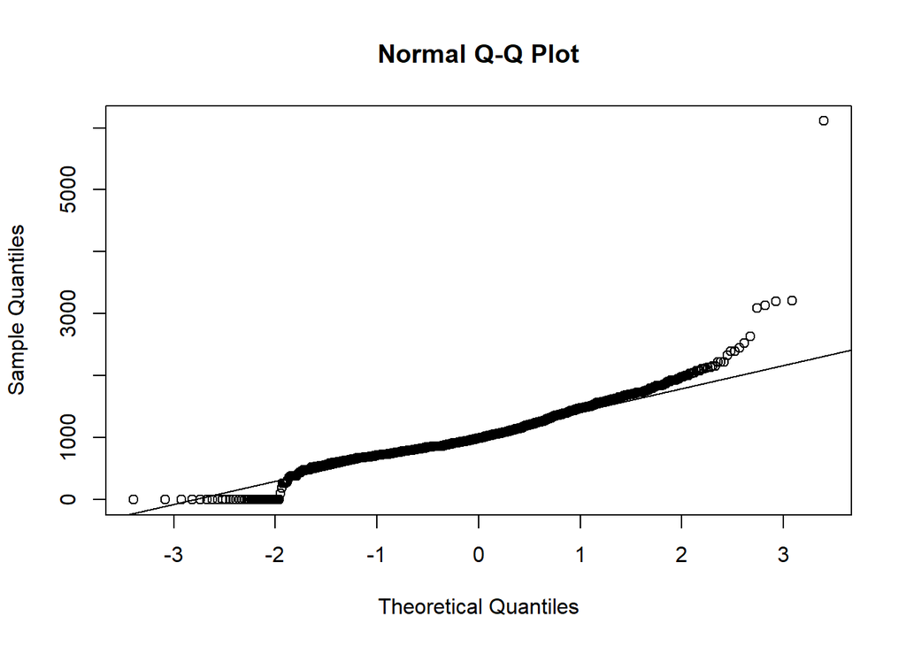

```
##
##  Lilliefors (Kolmogorov-Smirnov) normality test
##
## data:  datos$TotalBsmtSF
## D = 0.075952, p-value < 2.2e-16
```

###X1stFlrSF

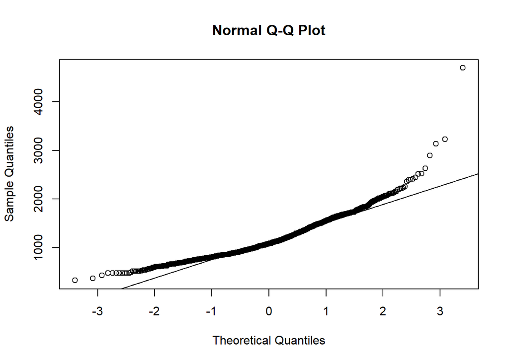

```
##
##  Lilliefors (Kolmogorov-Smirnov) normality test
##
## data:  datos$X1stFlrSF
## D = 0.086921, p-value < 2.2e-16
```

###X2ndFlrSF

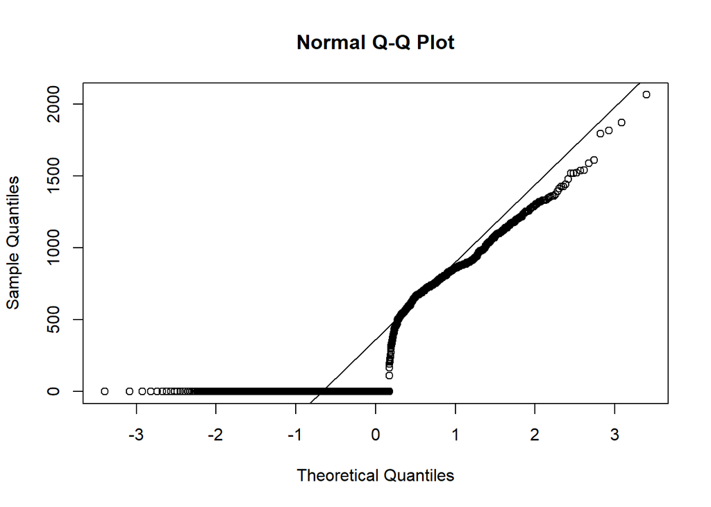

```
##
##  Lilliefors (Kolmogorov-Smirnov) normality test
##
## data:  datos$X2ndFlrSF
## D = 0.35447, p-value < 2.2e-16
```

###GrLivArea

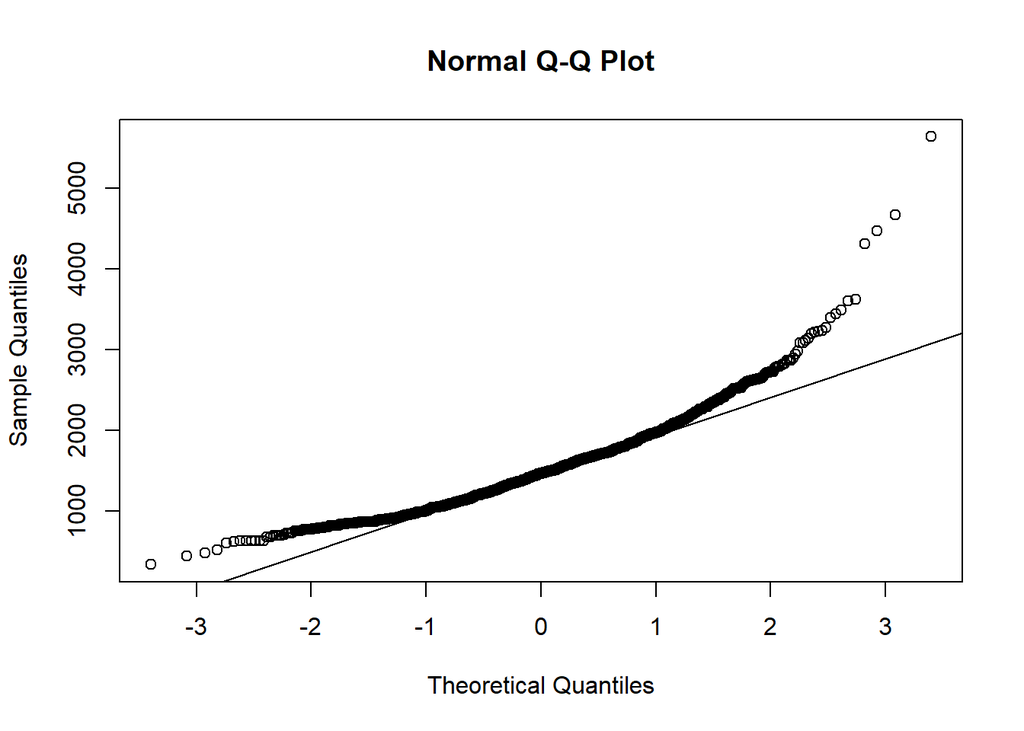

```
##
##  Lilliefors (Kolmogorov-Smirnov) normality test
##
## data:  datos$GrLivArea
## D = 0.067516, p-value < 2.2e-16
```

###BsmtFullBath

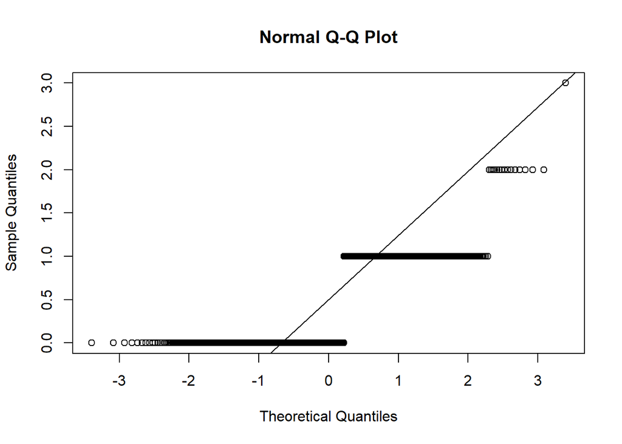

```
##
##  Lilliefors (Kolmogorov-Smirnov) normality test
##
## data:  datos$BsmtFullBath
## D = 0.3801, p-value < 2.2e-16
```

###BsmtHalfBath

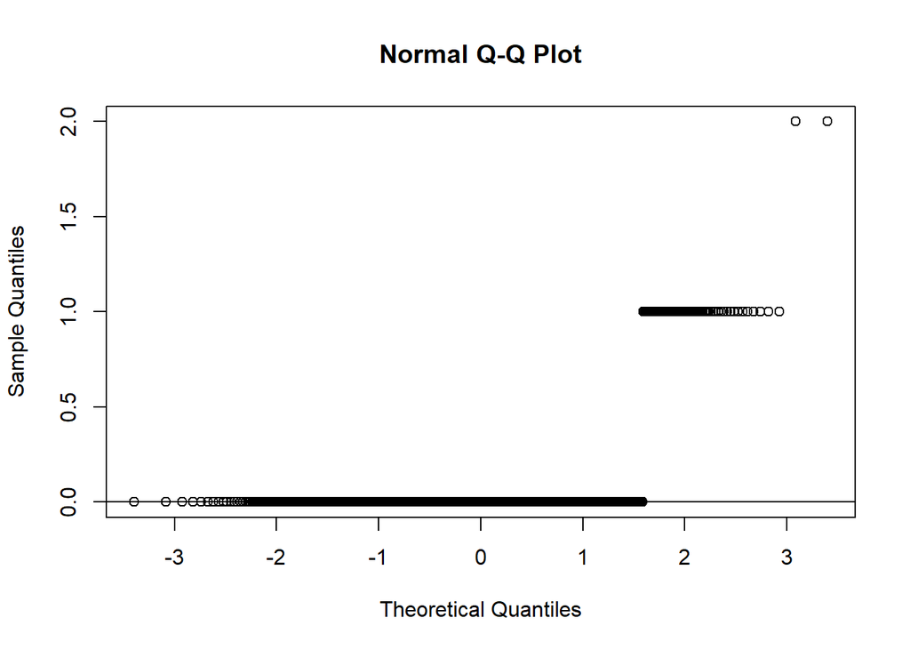

```
##
##  Lilliefors (Kolmogorov-Smirnov) normality test
##
## data:  datos$BsmtHalfBath
## D = 0.53905, p-value < 2.2e-16
```

###FullBath

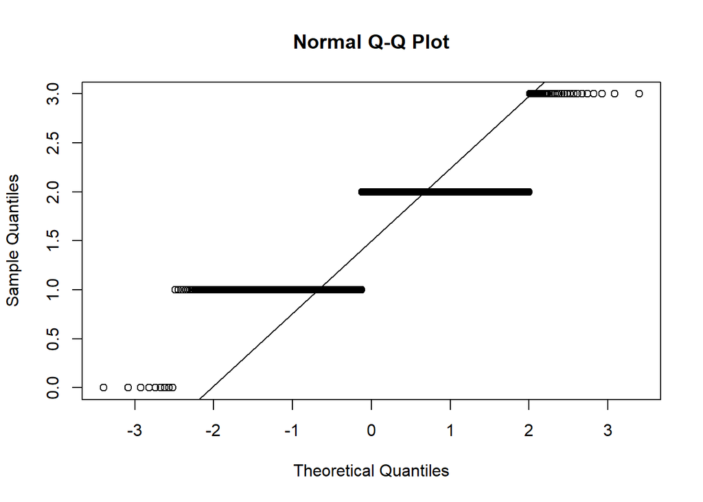

```
##
##  Lilliefors (Kolmogorov-Smirnov) normality test
##
## data:  datos$FullBath
## D = 0.33371, p-value < 2.2e-16
```

###HalfBath

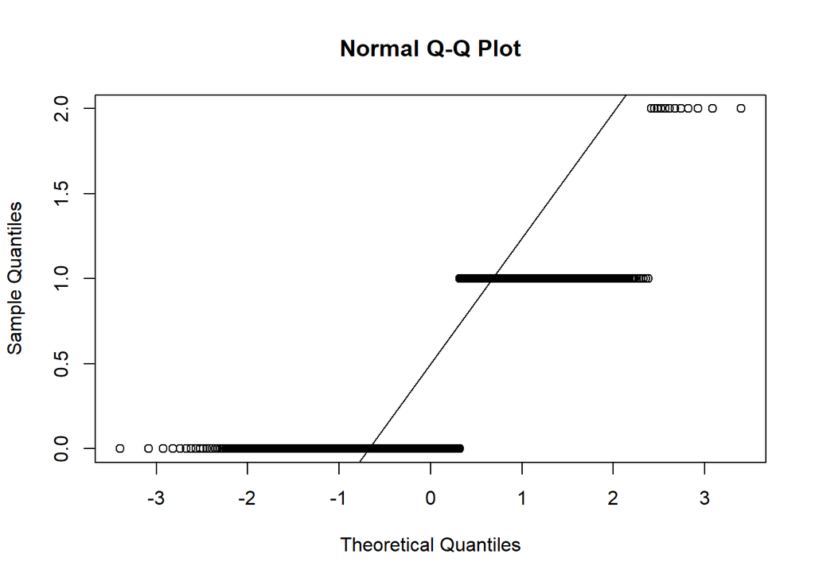

```
##
##  Lilliefors (Kolmogorov-Smirnov) normality test
##
## data:  datos$HalfBath
## D = 0.40212, p-value < 2.2e-16
```

###BedroomAbvGr

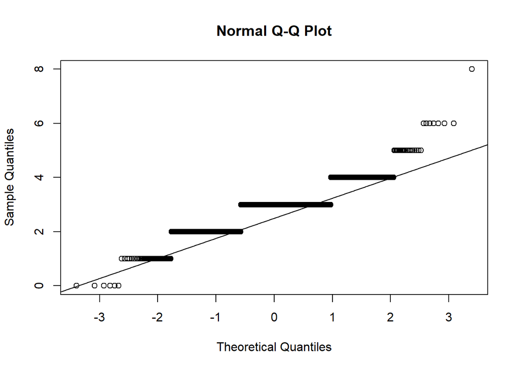

```
##
##  Lilliefors (Kolmogorov-Smirnov) normality test
##
## data:  datos$BedroomAbvGr
## D = 0.28146, p-value < 2.2e-16
```

###KitchenAbvGr

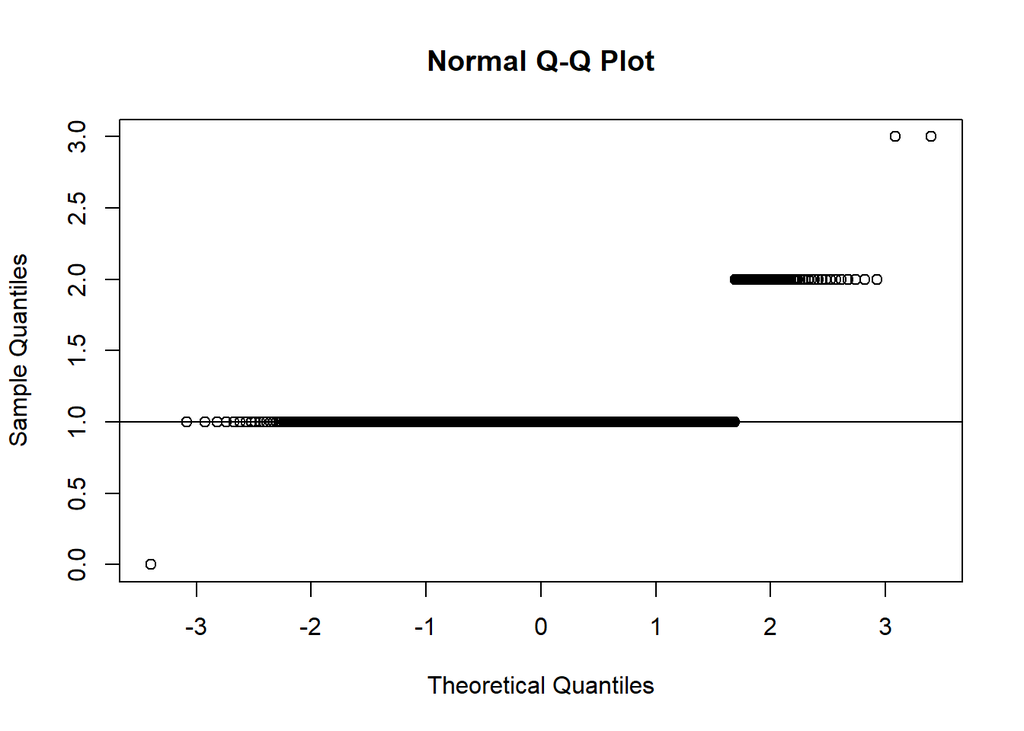

```
##
##  Lilliefors (Kolmogorov-Smirnov) normality test
##
## data:  datos$KitchenAbvGr
## D = 0.53781, p-value < 2.2e-16
```

###TotRmsAbvGrd

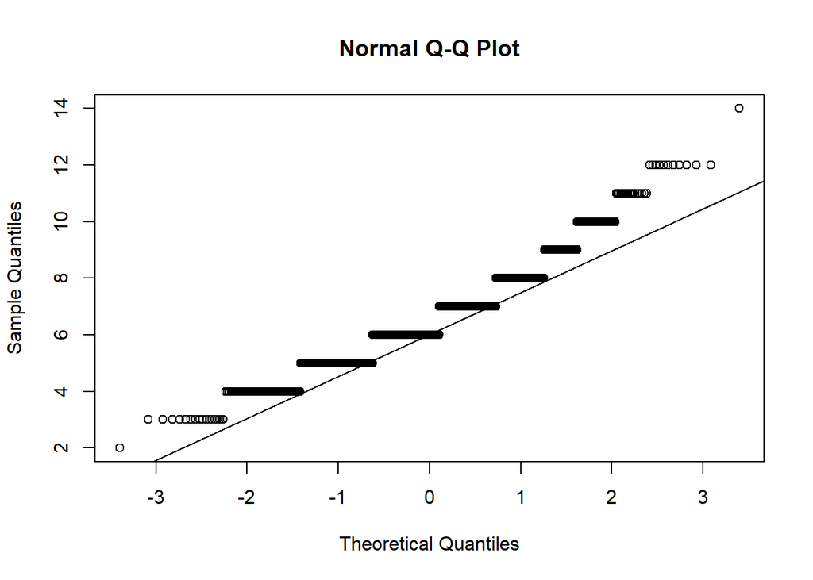

```
##
##  Lilliefors (Kolmogorov-Smirnov) normality test
##
## data:  datos$TotRmsAbvGrd
## D = 0.16744, p-value < 2.2e-16
```

###Fireplaces

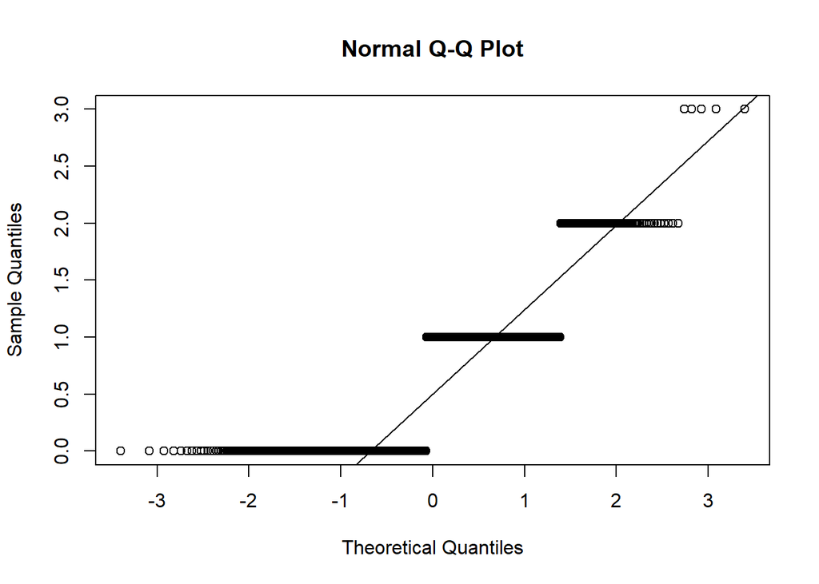

```
##
##  Lilliefors (Kolmogorov-Smirnov) normality test
##
## data:  datos$Fireplaces
## D = 0.30178, p-value < 2.2e-16
```

###TotRmsAbvGrd

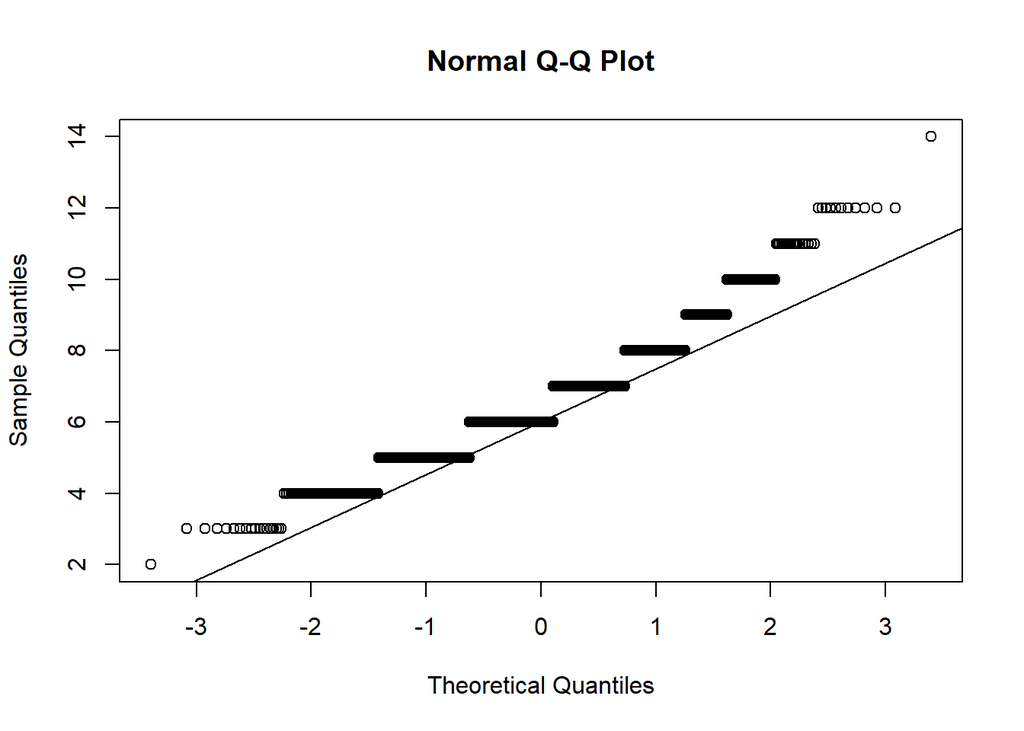

```
##
##  Lilliefors (Kolmogorov-Smirnov) normality test
##
## data:  datos$TotRmsAbvGrd
## D = 0.16744, p-value < 2.2e-16
```

###GarageYrBlt

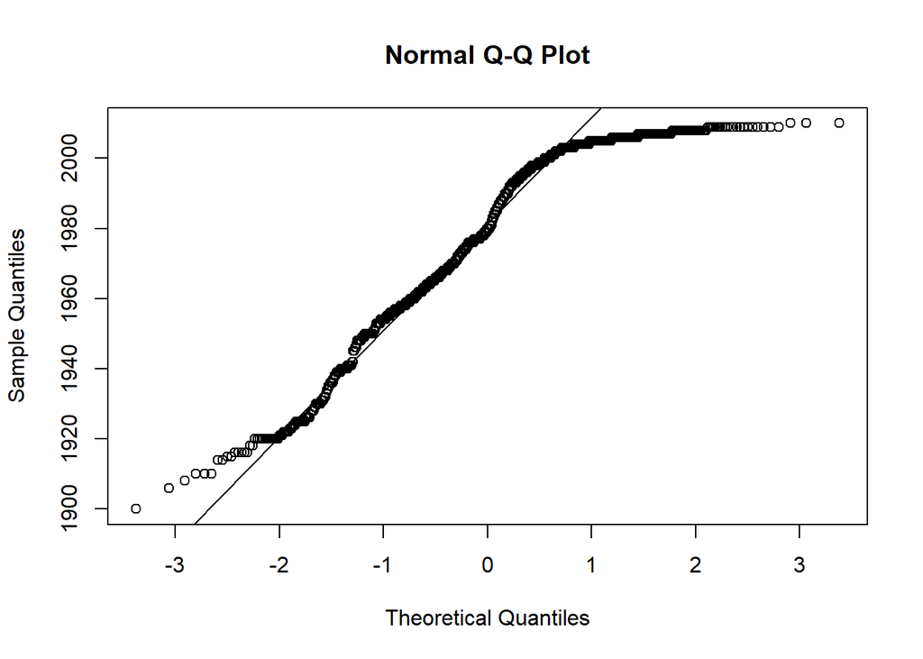

```
##
##  Lilliefors (Kolmogorov-Smirnov) normality test
##
## data:  datos$GarageYrBlt
## D = 0.1275, p-value < 2.2e-16
```

###GarageCars

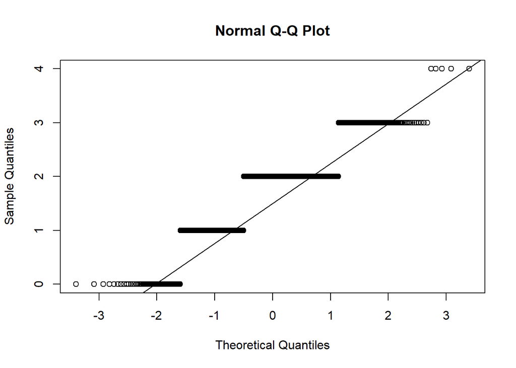

```
##
##  Lilliefors (Kolmogorov-Smirnov) normality test
##
## data:  datos$GarageCars
## D = 0.31412, p-value < 2.2e-16
```

###GarageArea

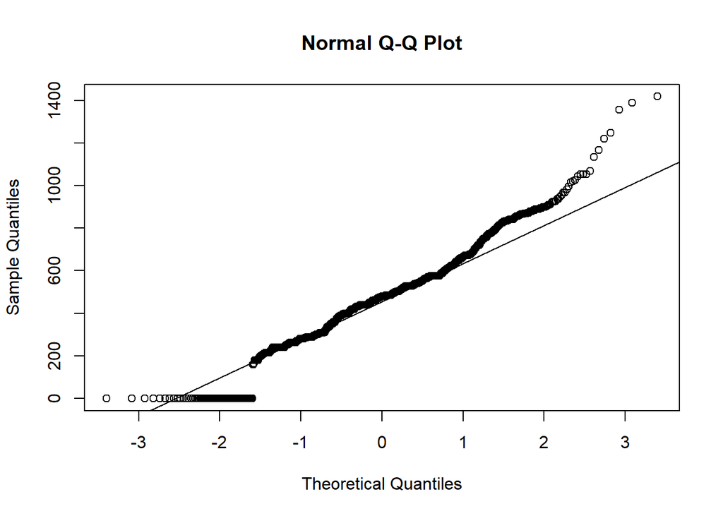

```
##
##  Lilliefors (Kolmogorov-Smirnov) normality test
##
## data:  datos$GarageArea
## D = 0.075343, p-value < 2.2e-16
```

###WoodDeckSF

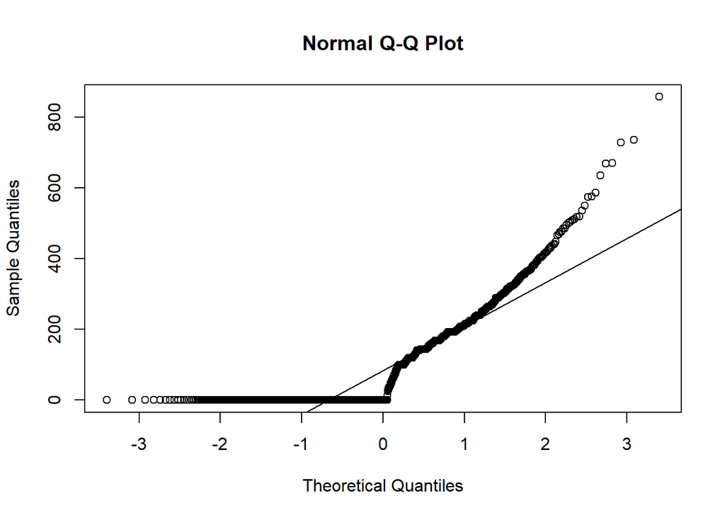

```
##
##  Lilliefors (Kolmogorov-Smirnov) normality test
##
## data:  datos$WoodDeckSF
## D = 0.29518, p-value < 2.2e-16
```

###EnclosedPorch

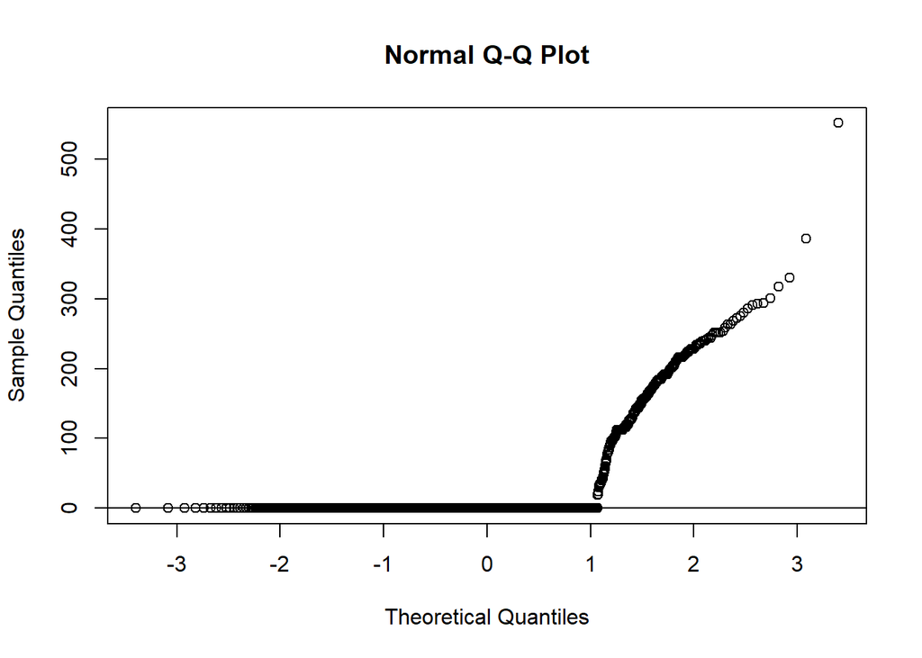

```
##
##  Lilliefors (Kolmogorov-Smirnov) normality test
##
## data:  datos$EnclosedPorch
## D = 0.49781, p-value < 2.2e-16
```

###OpenPorchSF

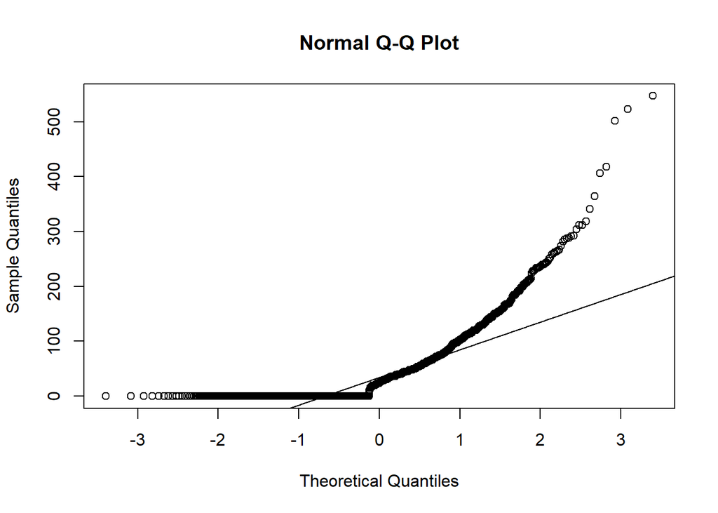